### Phenotype association analysis

Finally, let’s see which haplotype has superiority at particular area by interact with phynotype.

Here are two options, merged or separated, to organized the heatmap of p-values and violin plot. The figure as an object of `ggplot2`, which means user could add/modified figure elements with `ggplot2`.

Here is an example for merged arrangement:

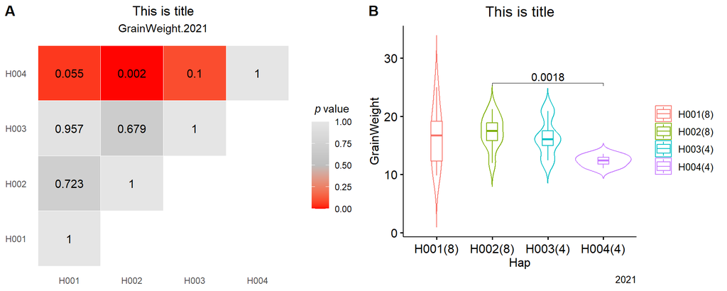

```r
results <-hapVsPheno(hapResult,
                     hapPrefix = "H",
                     title = "This is title",
                     mergeFigs = TRUE,
                     pheno = pheno,
                     phenoName = "GrainWeight.2021",
                     minAcc = 3)
plot(results$figs)
```

**An example for separated plot:**

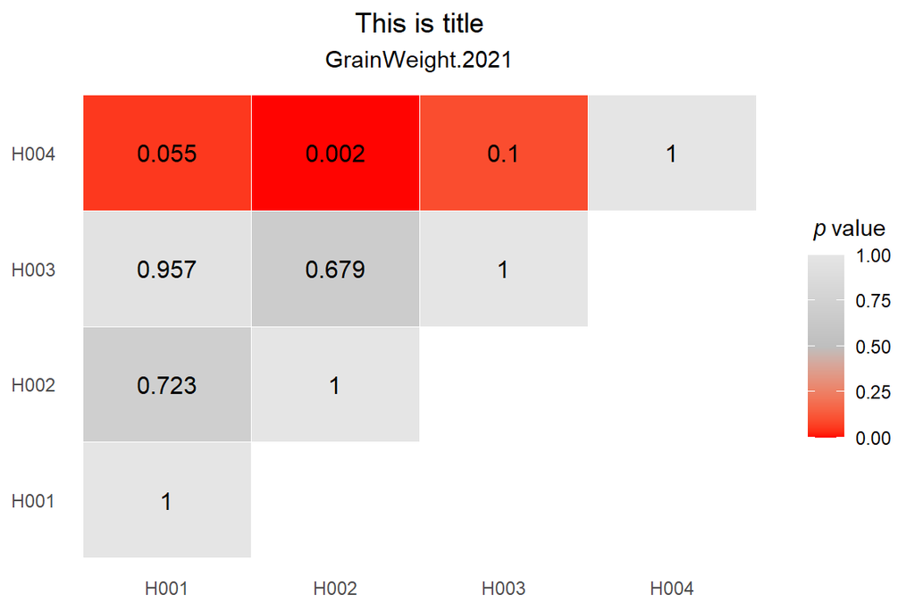

```r
results <- hapVsPheno(hap = hapResult,
                      hapPrefix = "H",
                      title = "This is title",
                      pheno = pheno,
                      phenoName = "GrainWeight.2021",
                      minAcc = 3,
                      mergeFigs = FALSE)
plot(results$fig_pvalue)
```

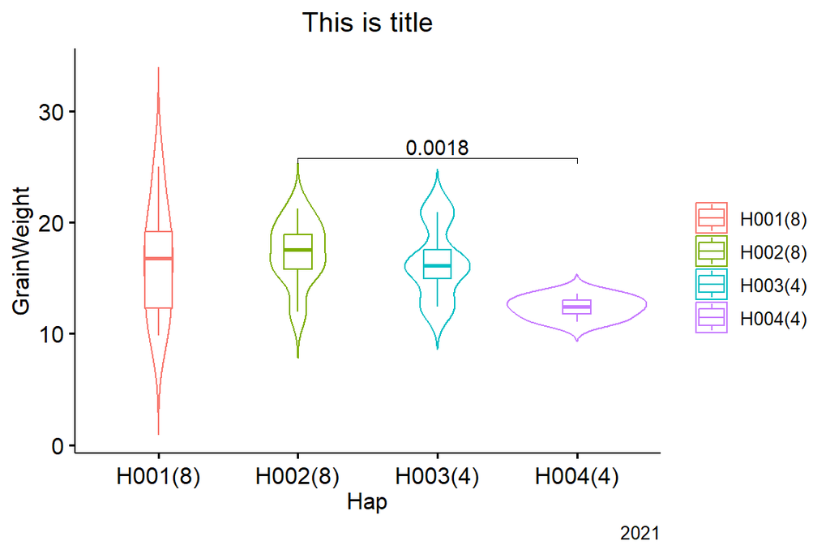

```r
plot(results$fig_Violin)
```

### Association analysis of multi-phenotypes once a time

I believe the function of `hapVsPhenos()` will be useful there are a lot of phenotype need to be associated with haplotype results.

Note that: the pheno name will be added between the file name and surfix.

```r
hapVsPhenos(hapResult,
            pheno,
            outPutSingleFile = TRUE,
            hapPrefix = "H",
            title = "Seita.0G000000",
            file = "mypheno.tiff",
            width = 12,
            height = 8,
            res = 300)
```